# Data Analysis with python

**Suggested Questions for Analysis:**

- Salary Trends: How have data science salaries changed over the years (2020, 2021, etc.)?
- Experience Level Impact: How does the salary vary with different experience levels (e.g., Entry-level, Mid-level, Senior)?
- Job Title Analysis: Which data science job titles tend to have the highest salaries?
- Geographical Influence: How do salaries differ across different countries or regions?
- Remote Work Impact: Is there a correlation between the ability to work remotely (remote ratio) and salary?
- Employment Type: How do salaries compare between full-time, part-time, and contract workers in data science?
- Company Size Effect: Does the size of the company (small, medium, large) affect the salary of data scientists?

## Proccessing Pandas Data frame

- cleaning data(handling NA's and duplicates etc..)
- grouping and merging data

loading the ds_salaries into the data frame:

```python
import pandas as pd

# Loading the dataset
data = pd.read_csv('/workspaces/codespaces-jupyter/data/ds_salaries.csv')

# Preliminary cleaning
data.drop(columns=['Unnamed: 0'], inplace=True)  # Removing an unnecessary column
data.dropna(inplace=True)  # Removing any rows with missing values

# Display the first few rows to verify changes
print(data.head())
```

```
   work_year experience_level employment_type                   job_title  \
0       2020               MI              FT              Data Scientist
1       2020               SE              FT  Machine Learning Scientist
2       2020               SE              FT           Big Data Engineer
3       2020               MI              FT        Product Data Analyst
4       2020               SE              FT   Machine Learning Engineer

   salary salary_currency  salary_in_usd employee_residence  remote_ratio  \
0   70000             EUR          79833                 DE             0
1  260000             USD         260000                 JP             0
2   85000             GBP         109024                 GB            50
3   20000             USD          20000                 HN             0
4  150000             USD         150000                 US            50

  company_location company_size
0               DE            L
1               JP            S
2               GB            M
3               HN            S
4               US            L
```

Data preprocessing is a crucial step in data analysis. It involves cleaning and formatting the data to remove any inaccuracies or inconsistencies. This step ensures that the analysis is performed on clean, reliable data. The process typically includes tasks like removing unnecessary columns and handling missing values.

## Exploratory Data Analysis

Now, let's perform some basic exploratory analysis.

```
         work_year        salary  salary_in_usd  remote_ratio
count   607.000000  6.070000e+02     607.000000     607.00000
mean   2021.405272  3.240001e+05  112297.869852      70.92257
std       0.692133  1.544357e+06   70957.259411      40.70913
min    2020.000000  4.000000e+03    2859.000000       0.00000
25%    2021.000000  7.000000e+04   62726.000000      50.00000
50%    2022.000000  1.150000e+05  101570.000000     100.00000
75%    2022.000000  1.650000e+05  150000.000000     100.00000
max    2022.000000  3.040000e+07  600000.000000     100.00000
```

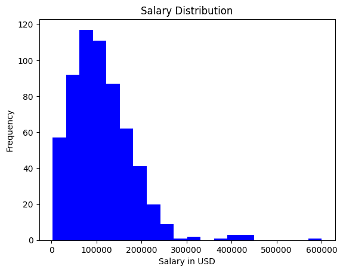

```python
import matplotlib.pyplot as plt

# Basic statistics
print(data.describe())

# Salary distribution
plt.hist(data['salary_in_usd'], bins=20, color='blue')
plt.title('Salary Distribution')
plt.xlabel('Salary in USD')
plt.ylabel('Frequency')
plt.show()
```

Exploratory Data Analysis is an approach for summarizing the main characteristics of a dataset, often with visual methods. A histogram, for example, is useful for visualizing the distribution of numerical data. The describe() function in Pandas provides a descriptive statistical summary of the dataset, which is helpful for a preliminary examination of the data.

## Querying and Insights

Answering some basic questions from our initial set.

```python
# Average salary by experience level
avg_salary_by_experience = data.groupby('experience_level')['salary_in_usd'].mean()
print(avg_salary_by_experience)

# Comparison of salaries by company size
avg_salary_by_company_size = data.groupby('company_size')['salary_in_usd'].mean()
print(avg_salary_by_company_size)
```

```
experience_level
EN     61643.318182
EX    199392.038462
MI     87996.056338
SE    138617.292857
Name: salary_in_usd, dtype: float64
company_size
L    119242.994949
M    116905.466258
S     77632.674699
Name: salary_in_usd, dtype: float64
```

Grouping data based on certain criteria can reveal patterns and insights. In this dataset, analyzing average salaries by experience level and company size can provide a deeper understanding of the factors that influence data science salaries.

## Data Analysis Insights and Storytelling

**Understanding the Landscape of Data Science Salaries**

This analysis delves into the intriguing world of data science salaries, uncovering patterns and insights that are pivotal for both aspiring and established data science professionals. Through our exploratory journey, we have leveraged the power of Python's Pandas and visualization libraries to extract meaningful stories from raw data.

**Key Insights from Our Analysis**

- Impact of Experience on Earning Potential:

A clear gradation in salaries emerged when we categorized data scientists by their experience level. This insight is particularly valuable for career path planning in data science, illustrating how investment in skill development can potentially lead to higher earning power.

- The Remote Work Factor:

In an increasingly remote-friendly world, our findings on the correlation between remote work opportunities and salary levels offer an interesting perspective on the future of work in data science.

- Company Size and Compensation:

The relationship between company size and salary revealed nuances in compensation strategies across different types of organizations. This could guide professionals in targeting their job search depending on their salary expectations.

**Conclusions and Future Directions**

The data analysis conducted not only answers specific questions about data science salaries but also paints a broader picture of the career landscape in this field. The insights gained can guide both individual career decisions and organizational strategies in compensation and talent acquisition.

For future research, extending this analysis with more granular data, such as specific roles within data science, educational background, and more detailed geographical data, could yield even deeper insights. Additionally, incorporating time-series analysis could provide predictions of future salary trends, which would be invaluable for strategic career planning and organizational forecasting.

## Visualization

Let's create a more advanced visualization.

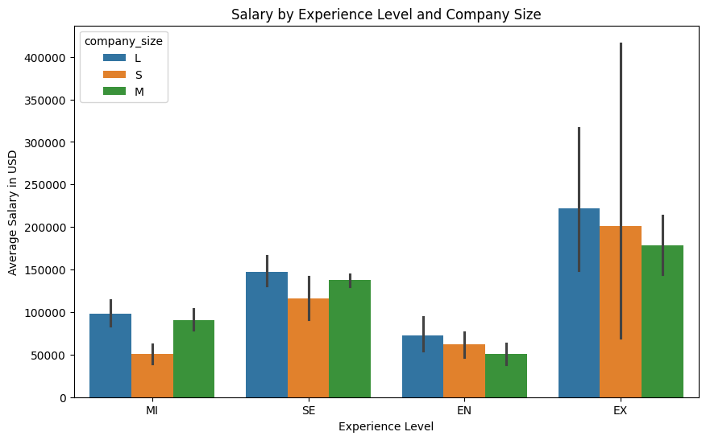

```python
# Salary by experience level and company size
import seaborn as sns

plt.figure(figsize=(10,6))
sns.barplot(x='experience_level', y='salary_in_usd', hue='company_size', data=data)
plt.title('Salary by Experience Level and Company Size')
plt.xlabel('Experience Level')
plt.ylabel('Average Salary in USD')
plt.show()
```

Advanced data visualization techniques can further illustrate the relationships within the data. Using libraries like Seaborn, which is built on Matplotlib, allows for creating more sophisticated visualizations. A bar plot, for instance, can effectively compare different categories and highlight the differences in a visually intuitive manner.

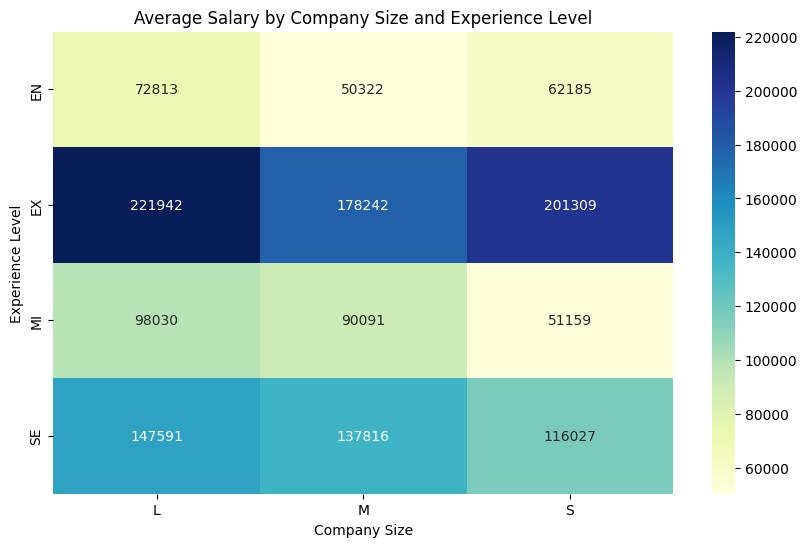

```python
import numpy as np

# Creating a pivot table
pivot_table = data.pivot_table(values='salary_in_usd', index='experience_level', columns='company_size', aggfunc=np.mean)

# Plotting the heatmap
plt.figure(figsize=(10, 6))
sns.heatmap(pivot_table, annot=True, fmt=".0f", cmap="YlGnBu")
plt.title('Average Salary by Company Size and Experience Level')
plt.xlabel('Company Size')
plt.ylabel('Experience Level')
plt.show()
```

A heatmap is used here to visualize the average salary across different combinations of company size and experience level, highlighting potential trends and outliers.

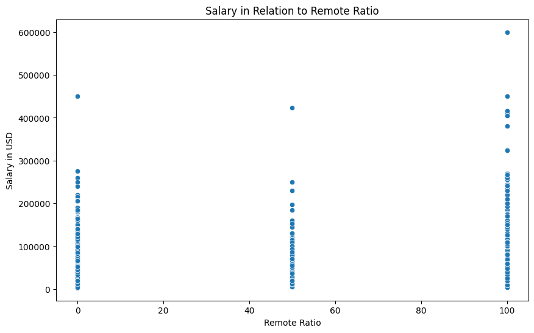

```python
plt.figure(figsize=(10, 6))
sns.scatterplot(x='remote_ratio', y='salary_in_usd', data=data)
plt.title('Salary in Relation to Remote Ratio')
plt.xlabel('Remote Ratio')
plt.ylabel('Salary in USD')
plt.show()
```

A scatter plot is used to explore any potential correlation between the salary and the remote work ratio, providing insights into how remote work may impact compensation